# Mental_Imagery_analysis

# Analysis

## Preparing the Data

### Librarys used

```r
#setwd("~/Mental_Imagery_Experiment")
library(tidyverse)

library(rstan)
# set cores to use to the total number of cores (minimally 4)
options(mc.cores = max(parallel::detectCores(), 4))
# save a compiled version of the Stan model file
rstan_options(auto_write = TRUE)

library(brms)

# install faintr with
#install.packages("HDInterval")
#devtools::install_github('michael-franke/bayes_mixed_regression_tutorial/faintr', build_vignettes = TRUE)
library(faintr)
library(reshape2)


set.seed(123)
```

### Reading data

```r
# your code here

#data <- read_csv("C:/Users/leado/XP_Lab/Mental_Imagery_Experiment/data/results_72_Mental_Imagery_Experiment_Sveana+Spellbanovicz.csv")
data %>% glimpse()

#Sven PC1
#data <- read_csv("C:/Users/Groen/Documents/Mental_Imagery_Experiment/data/results_72_Mental_Imagery_Experiment_Sveana+Spellbanovicz.csv")
# data %>% glimpse()

#Sven PC2
data <- read_csv("C:/Users/SvenG/OneDrive/Sommersemester 2019/Experimental Psychology/Mental_Imagery_Experiment/data/results_72_Mental_Imagery_Experiment_Sveana+Spellbanovicz.csv")

data %>% glimpse()
```

```
## function (..., list = character(), package = NULL, lib.loc = NULL,
##     verbose = getOption("verbose"), envir = .GlobalEnv, overwrite = TRUE)
## Observations: 3,906
## Variables: 37
## $ submission_id     <dbl> 590, 590, 590, 590, 590, 590, 590, 590, 590,...
## $ question          <chr> "<b>Klang / Geräusch</b> von: Auf die Straße...
## $ startDate         <chr> "Sat Jul 13 2019 02:53:38 GMT+0200 (CEST)", ...
## $ experiment_id     <dbl> 72, 72, 72, 72, 72, 72, 72, 72, 72, 72, 72, ...
## $ listening_foreign <dbl> 6, 6, 6, 6, 6, 6, 6, 6, 6, 6, 6, 6, 6, 6, 6,...
## $ optionRight       <chr> "eine perfekt klare Vorstellung", "eine perf...
## $ writing_native    <dbl> 7, 7, 7, 7, 7, 7, 7, 7, 7, 7, 7, 7, 7, 7, 7,...
## $ id                <dbl> 1, 6, 4, 2, 5, 3, 0, 14, 16, 9, 38, 34, 27, ...
## $ listening_time    <dbl> 4, 4, 4, 4, 4, 4, 4, 4, 4, 4, 4, 4, 4, 4, 4,...
## $ reading_native    <dbl> 6, 6, 6, 6, 6, 6, 6, 6, 6, 6, 6, 6, 6, 6, 6,...
## $ speaking_time     <dbl> 2, 2, 2, 2, 2, 2, 2, 2, 2, 2, 2, 2, 2, 2, 2,...
```

[output cut: 26 more lines]

### Preparing for Analysis

```r
#selecting relevant columns
s_data <- select(data, submission_id, trial_name, id, type, response, RT, language, native_language, foreign_language, foreign_dominance, speaking_native, listening_native, writing_native, reading_native, speaking_foreign, listening_foreign, writing_foreign, reading_foreign, reading_time, listening_time, speaking_time, learning_time,age,education, gender,timeSpent) %>% filter(trial_name == "ratingScaleTask")

#here we change the types of the variables
m_data <- mutate(s_data, trial_name = factor(trial_name), type = factor(type), exp_language= language, foreign_dominance = factor(foreign_dominance), subject_id = as.numeric(submission_id), response = factor(response, ordered=TRUE), experiment_id = NULL, language = NULL, submission_id = NULL, id = factor(id),native_language = factor(native_language), foreign_language=factor(foreign_language) , education = factor(education), gender = factor(gender))


#check if the foreign or native language is used in this experiment and add the new column
# if TRUE than the experiment was performend in the native language, else it was performed in the foreign language
m_data <- m_data %>%
  mutate(language_eq = (exp_language == native_language))

#filter out the trial tasks as they are irrelevant for us
m_data <- m_data %>% filter(trial_name == "ratingScaleTask")
```

## Exclusion Criteria:

```r
#Counting number of overall excluded participants
start_participants = nrow(unique(m_data[,"subject_id"]))
start_num_sentences = nrow(m_data)
```

### a. Excluding Criteria regarding the participants:

#### Criteria i:

Participants having neither English nor German as native language are going to be excluded from the analysis

```r
a = nrow(unique(m_data[,"subject_id"]))
print(paste("Number of Participants before exclusion i: ", a))

#Exclude
new_data <- m_data %>% filter(native_language == "German" | native_language == "English")

b= nrow(unique(new_data[,"subject_id"]))
print(paste("Number of Participants after exclusion i: ", b))
print(paste("Excluded: ", a-b))
```

```
## [1] "Number of Participants before exclusion i:  93"
## [1] "Number of Participants after exclusion i:  87"
## [1] "Excluded:  6"
```

#### Criteria ii:

Participants having neither English nor German as a foreign language are going to be excluded from the analysis

```r
a = nrow(unique(new_data[,"subject_id"]))
print(paste("Number of Participants before exclusion ii: ", a))


#Exclude
new_data <- new_data %>% filter(foreign_language == "German" | foreign_language == "English")

b= nrow(unique(new_data[,"subject_id"]))
print(paste("Number of Participants after exclusion ii: ", b))
print(paste("Excluded: ", a-b))
```

```
## [1] "Number of Participants before exclusion ii:  87"
## [1] "Number of Participants after exclusion ii:  82"
## [1] "Excluded:  5"
```

#### Criteria iii:

Participants where their foreign language is their dominant language are going to be excluded: Participants that have spoken their foreign language in their homes and/or if they are speaking in their foreign language more often (in their daily life) than their actual native language are going to be excluded from the analysis

```r
a = nrow(unique(new_data[,"subject_id"]))
print(paste("Number of Participants before exclusion iii: ", a))


#Exclude
new_data <- new_data %>% filter(foreign_dominance == 'no')

b= nrow(unique(new_data[,"subject_id"]))
print(paste("Number of Participants after exclusion iii: ", b))
print(paste("Excluded: ", a-b))
```

```
## [1] "Number of Participants before exclusion iii:  82"
## [1] "Number of Participants after exclusion iii:  76"
## [1] "Excluded:  6"
```

#### Criteria iv:

Exclude any participant which native language is equal to their foreign language

```r
a = nrow(unique(new_data[,"subject_id"]))
print(paste("Number of Participants before exclusion iV: ",nrow(unique(new_data[,"subject_id"]))))

#transform to string so they can be compared
new_data <- new_data %>%  mutate(native_language = as.character(native_language), foreign_language = as.character(foreign_language))

#Exclude
new_data <- new_data %>% filter(native_language != foreign_language)

b= nrow(unique(new_data[,"subject_id"]))
print(paste("Number of Participants after exclusion iV: ", b))
print(paste("Excluded: ", a-b))
```

```
## [1] "Number of Participants before exclusion iV:  76"
## [1] "Number of Participants after exclusion iV:  75"
## [1] "Excluded:  1"
```

### Specific Criteria:

#### Criteria i:

If a participant has chosen the exact same rating in 95% or more of the 35 stimuli (≥ 95% of the same rate), then this participant is going to be excluded from the analysis

```r
a = nrow(unique(new_data[,"subject_id"]))
print(paste("Number of Participants before exclusion i: ", a))


# CHECK 95% the same answer
# only check main trials and look at subject id
e_data <- group_by(new_data, subject_id)
e_data <- subset(e_data,select = c(response, subject_id))

# get matrix that shows how often a subject clicked each level of vividness
t1 <- table(e_data)
t1 <- as.data.frame.matrix(t1)



# check if one level was chosen more than 95% (>= 33) and safe index
b <- which(t1 >= 32, arr.ind=T)
# save name of columns that have to be deleted
col_names <-colnames(t1[unique(b[,"col"])])

new_data <- new_data[!(new_data$subject_id %in% col_names),]

b= nrow(unique(new_data[,"subject_id"]))
print(paste("Number of Participants after exclusion i: ", b))
print(paste("Excluded: ", a-b))
```

```
## [1] "Number of Participants before exclusion i:  75"
## [1] "Number of Participants after exclusion i:  75"
## [1] "Excluded:  0"
```

#### Criteria ii:

If a participant has chosen the option “I don’t understand the sentence” 5 times or more (≥ 5x “I don’t understand”), then this participant is going to be excluded from the analysis

```r
a = nrow(unique(new_data[,"subject_id"]))
print(paste("Number of Participants before exclusion ii: ", a))

# only check main trials and look at subject id
e_data2 <- group_by(new_data, subject_id)
e_data2 <- subset(e_data2,select = c(response, subject_id))

# CHECK IF 5 or more times "i dont know the answer" was chosen
t2 <- table(e_data2)
t2 <- as.data.frame.matrix(t2)

# check given row was chosen more 5 times and safe index
row <- 1
c <- which(t2[row,] >= 5, arr.ind=T)
# save name of columns that have to be deleted

col_names2 <- colnames(t2[unique(c[,"col"])])
new_data <- new_data[!(new_data$subject_id %in% col_names2),]

b= nrow(unique(new_data[,"subject_id"]))
print(paste("Number of Participants after exclusion ii: ", b))
print(paste("Excluded: ", a-b))
```

```
## [1] "Number of Participants before exclusion ii:  75"
## [1] "Number of Participants after exclusion ii:  74"
## [1] "Excluded:  1"
```

#### Criteria iii:

We are going to look at the overall distribution of data and exclude every trial of a participant that deviates three standard deviations above and below the mean with respect to the participants’ reaction time. If for one participant there are five trials or more where the reaction time deviates three standard deviations above and below the mean reaction time, the whole participant is going to be excluded from the analysis. We will also check how the analysis differs with and without these participants.

```r
a = nrow(unique(new_data[,"subject_id"]))
print(paste("Number of Participants before exclusion iii: ", a))

#get sd and mean
std<-apply(new_data[5], 2, sd)
mean <- apply(new_data[5], 2, mean)
lower_bound = mean-3*std
upper_bound = mean+3*std

std_excl <- new_data %>% mutate(RT_exc_critieria =RT <= lower_bound || RT >= upper_bound)%>% group_by(subject_id) %>% subset(select = c(RT_exc_critieria, subject_id))


t3 <- table(std_excl) %>% as.data.frame.matrix()


# only continue if there are at least one exclusions at all (else the table does not have the TRUE row)
if(nrow(t3 == 2)){
  d <- which(t3["TRUE",] >= 5, arr.ind=T)
  # save name of columns that have to be deleted
  col_names3 <- colnames(t3[unique(d[,"col"])])
  #exclude
  new_data <- new_data[!(new_data$subject_id %in% col_names3),]
}

b= nrow(unique(new_data[,"subject_id"]))
print(paste("Number of Participants after exclusion iii: ", b))
print(paste("Excluded: ", a-b))
```

```
## [1] "Number of Participants before exclusion iii:  74"
## [1] "Number of Participants after exclusion iii:  74"
## [1] "Excluded:  0"
```

#### Criteria iv:

Any sentence that received the response “I don’t understand the sentence” is useless for our purpose of analysis, thus for each participant that was not excluded via ii. but made use of this choice, the respective sentence(s) are excluded from the participants analysis, however the remaining ones are used.

```r
a = nrow(new_data)
new_data <- new_data %>% filter(response != 0) %>%  mutate(response=factor(response,levels = c(1,2,3,4,5,6,7)))

b = a - nrow(new_data)

print(paste("number of excluded sentences: ", b))
```

```
## [1] "number of excluded sentences:  48"
```

### Results of Exclusion:

```r
# Count how many participants have been excluded:
num_excluded = nrow(unique(m_data[,"subject_id"]))-nrow(unique(new_data[,"subject_id"]))
print(paste("Started with ", start_participants, " participants"))
print(paste("Overall Number of excluded participants: ", num_excluded))
print(paste("Remaining number of Participants: ", start_participants - num_excluded))
exc_sentences = start_num_sentences - nrow(new_data)
print(paste("Started with ", start_num_sentences, " sentences"))
print(paste("Overall number of removed sentences", exc_sentences))
print(paste("Remaining number of sentences", nrow(new_data)))
```

```
## [1] "Started with  93  participants"
## [1] "Overall Number of excluded participants:  19"
## [1] "Remaining number of Participants:  74"
## [1] "Started with  3255  sentences"
## [1] "Overall number of removed sentences 713"
## [1] "Remaining number of sentences 2542"
```

## Getting an Overview of the Data

### Looking at the data for each participant

```r
d_individual_summary <- new_data  %>% group_by(subject_id) %>% mutate(response=as.integer(response)) %>% summarize(mean_RT = mean(RT), timeSpent=mean(timeSpent), writing_foreign = mean(writing_foreign), speaking_foreign= mean(speaking_foreign), listening_foreign = mean(listening_foreign), writing_native = mean(writing_native), speaking_native = mean(speaking_native),listening_native = mean(listening_native),reading_time = mean(reading_time), listening_time= mean(listening_time), speaking_time = mean(speaking_time), learning_time=mean(learning_time), age = mean(age), education = unique(education),gender = unique(gender), exp_language = unique(exp_language), native_language = unique(native_language), foreign_language= unique(foreign_language), language_eq = (exp_language == native_language),response=mean(response))

#gender was presented in German and English
#this translates the german version into english
d_individual_summary$gender <- ifelse(d_individual_summary$gender == "männlich" & d_individual_summary$gender != "male" & d_individual_summary$gender != "female", "male","female")

#same with education:
for (i in 1:nrow(d_individual_summary)){

  if(!is.na(d_individual_summary[i,"education"]) & d_individual_summary[i,"education"] == "anderes")
  {d_individual_summary[i,"education"] = "other"}
  if(!is.na(d_individual_summary[i,"education"]) & d_individual_summary[i,"education"] == "Abitur")
  {d_individual_summary[i,"education"] = "Graduated High School (Abitur)"}
  if(!is.na(d_individual_summary[i,"education"]) & d_individual_summary[i,"education"] == "Hochschulabschluss (Bachelor/Master)")
  {d_individual_summary[i,"education"] = "Graduated College"}
  if(!is.na(d_individual_summary[i,"education"]) & d_individual_summary[i,"education"] == "Höherer Abschluss")
  {d_individual_summary[i,"education"] = "Higher Degree"}
}
d_individual_summary
```

```
## # A tibble: 74 x 21
##    subject_id mean_RT timeSpent writing_foreign speaking_foreign
##         <dbl>   <dbl>     <dbl>           <dbl>            <dbl>
##  1        442   6831.      8.00               6                5
##  2        443  24457.     26.8                6                5
##  3        444  12332.     10.9                5                4
##  4        445   7434.      9.47               4                5
##  5        446   6508.      8.32               4                3
##  6        448   7993.      8.61               5                5
##  7        449   6090.      8.91               6                5
##  8        450   5735.      7.32               6                6
##  9        451   5492.      7.95               5                6
## 10        452   3342.      4.76               5                5
## # ... with 64 more rows, and 16 more variables: listening_foreign <dbl>,
## #   writing_native <dbl>, speaking_native <dbl>, listening_native <dbl>,
## #   reading_time <dbl>, listening_time <dbl>, speaking_time <dbl>,
## #   learning_time <dbl>, age <dbl>, education <fct>, gender <chr>,
## #   exp_language <chr>, native_language <chr>, foreign_language <chr>,
## #   language_eq <lgl>, response <dbl>
```

### Gender distribution

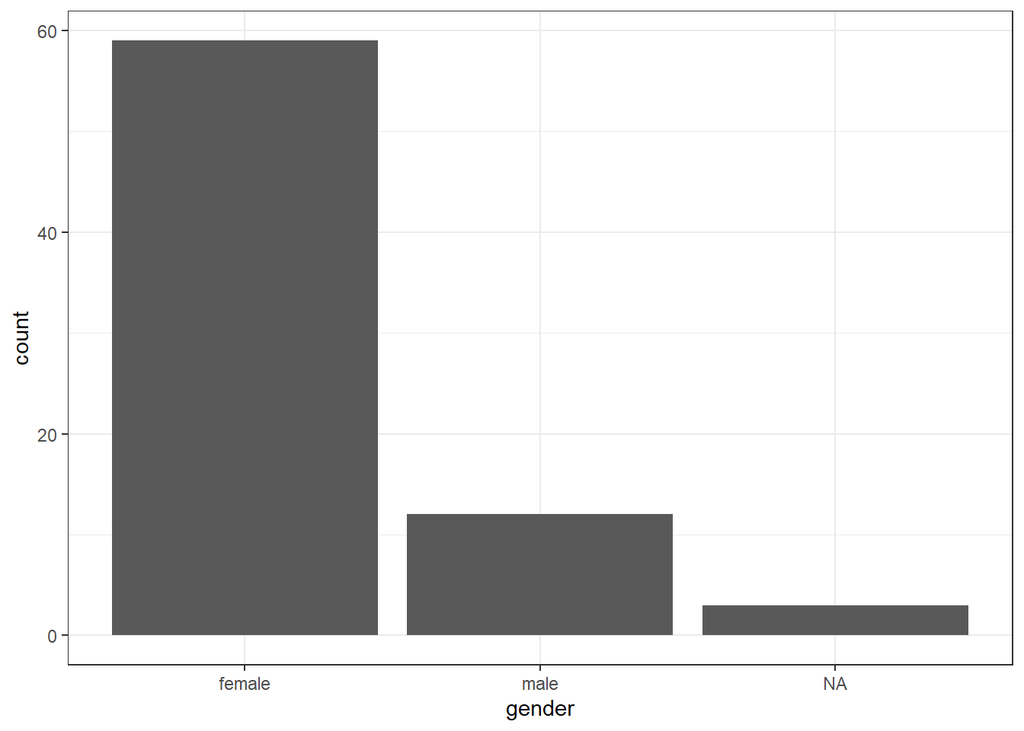

```r
d_individual_summary %>% ggplot(aes(x=gender)) + theme_bw() + geom_bar()
```

```r
d_individual_summary %>% group_by(gender) %>% summarise(gender_count = n())
```

```
## # A tibble: 3 x 2
##   gender gender_count
##   <chr>         <int>
## 1 female           59
## 2 male             12
## 3 <NA>              3
```

### Education Distribution

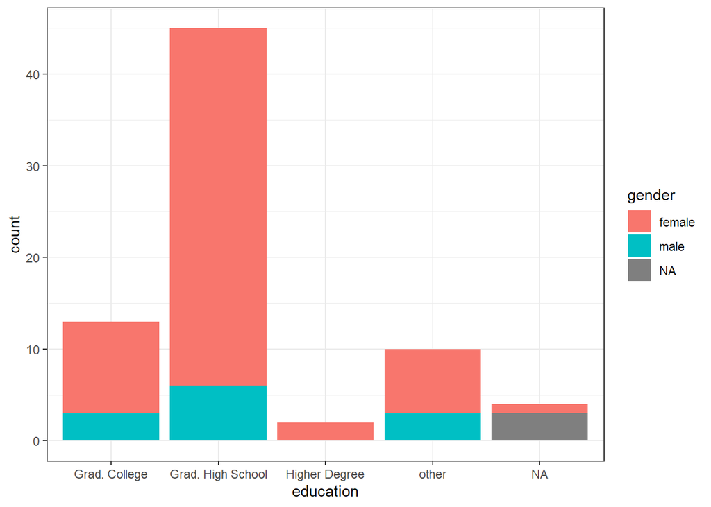

```r
d_individual_summary %>% ggplot(aes(x=education, fill = gender)) + theme_bw() + geom_bar() +  scale_x_discrete(labels=c("Grad. College", "Grad. High School", "Higher Degree", "other","NA"))
```

```r
d_individual_summary %>% group_by(education) %>% summarise(education_count = n())
```

```
## # A tibble: 5 x 2
##   education                      education_count
##   <fct>                                    <int>
## 1 Graduated College                           13
## 2 Graduated High School (Abitur)              45
## 3 Higher Degree                                2
## 4 other                                       10
## 5 <NA>                                         4
```

### Age Distribution

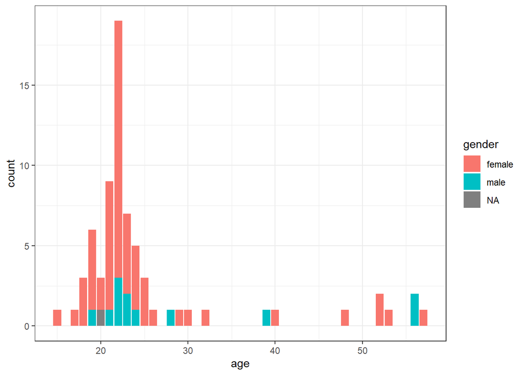

```r
#Barplot
ggplot(d_individual_summary, aes(x=age, fill=gender)) + theme_bw() + geom_bar()
```

```r
age_mean <- d_individual_summary[ , c("age")] %>% na.omit() %>% apply(2, FUN = mean)
age_median <- d_individual_summary[ , c("age")] %>% na.omit() %>% apply(2, FUN = median)


print(paste("The average age of our participants is: ",
age_mean, "years"))
print(paste("and the media age of our participants is: ",
age_median))
```

```
## [1] "The average age of our participants is:  25.6478873239437 years"
## [1] "and the media age of our participants is:  22"
```

One can see that the majority of our participants is around 22 years old.

### Participants’ Comments

```r
comm <- setNames(data.frame(matrix(ncol = 6, nrow = 0)), c("comments", "submission_id", "education", "native_language", "foreign_language", "foreign_dominance"))

for (i in 1:nrow(data)){
  if (!is.na(data[i,"comments"])){
    new_row <- data.frame("comments" = data[i,"comments"], "submission_id" = data[i,"submission_id"], "education" = data[i,"education"], "native_language" = data[i,"native_language"], "foreign_language" = data[i,"foreign_language"], "foreign_dominance" = data[i,"foreign_dominance"])

    comm <- rbind(comm, new_row) %>% unique()
  }
}

comm
```

```
##                                                                                                                                                                                                                                                                                                   comment…
## 1 Ich spreche Deutsch als Heritage-speaker, also ist es keine richtige Fremdsprache aber auch nicht so perfekt wie meine Muttersprache. \\n\\nBei manchen (visuelle) Vorstellungen konnte ich eine Person gut aber eine andere nur schlecht visualisieren, obwohl ich mit beiden sehr viel Zeit verbringe…
## 2                                                                                                                                                                Ein sehr interessanter Fragenkatalog. Und auch schön, dass daran erinnert wird, wie viel man sich eigentlich vorstellen kann und könnte …
## 3                                                                                                                                                                                                                                                      Kleiner Typfehler, man schreibt "vage" statt "wage…
## 4                                                                                                                                                                                                                                                        BA of Engineering FR Papiertechnik Abschluss 202…
## 5                                                                                                                                                                                                                            deutsch und englisch sind gleichermaßen Fremd - sowie Muttersprache für mich…
## 6                                                                                                                                                                                         Beim ausfüllen versehentlich mehrmals auf “ich verstehe den Satz nicht” statt eigentlich gewollter Zahl gekomme…
## 7                                                                                                                                                                                                                                                                                Du nennst mich Spitzkopf…
## 8                                                                                                                                                                                                                                                                             erweiteter Realschulabschlu…
## 9                                                                                                                                                                                                                                                                                         Ich mag Schinke…
##   submission_id                            education native_language
## 1           732                               Abitur            Both
## 2           632                               Abitur          German
## 3           694                               Abitur          German
## 4           600                               Abitur          German
## 5           667                               Abitur            Both
## 6           822                               Abitur          German
## 7           504 Hochschulabschluss (Bachelor/Master)          German
## 8           505                                other          German
## 9           525       Graduated High School (Abitur)          German
##   foreign_language foreign_dominance
## 1             None               yes
## 2          English                no
## 3          English                no
## 4             Both               yes
## 5             None              <NA>
## 6          English                no
## 7          English                no
## 8          English                no
## 9          English                no
```

### Language Levels

```r
d_individual_summary %>%  group_by(native_language) %>% summarise(language_exp_count = n())
d_individual_summary %>%  group_by(language_eq) %>% summarise(language_eq_count = n())
```

```
## # A tibble: 1 x 2
##   native_language language_exp_count
##   <chr>                        <int>
## 1 German                          74
## # A tibble: 2 x 2
##   language_eq language_eq_count
##   <lgl>                   <int>
## 1 FALSE                      27
## 2 TRUE                       47
```

We have only German native speaking participants. 27 participants performed the experiment in their foreign language (english) and 47 performed the experiment in their native language (47)

#### Subjective Language Proficiency

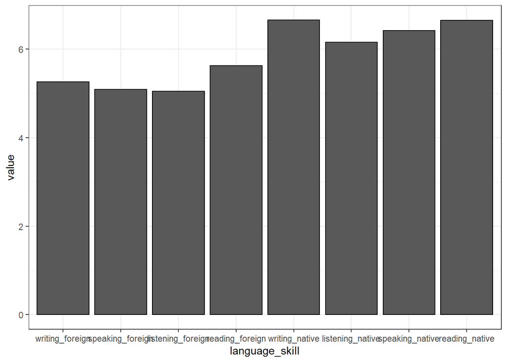

```r
language_summary <- (colMeans( m_data[ , c("writing_foreign", "speaking_foreign", "listening_foreign","reading_foreign", "writing_native", "listening_native","speaking_native","reading_native")],na.rm = TRUE)) %>% as.matrix()
colnames(language_summary) <- c("rating")


tmp<- melt(language_summary)
names(tmp) = c("language_skill", "", "value")


ggplot(tmp, aes(x=language_skill,y=value)) +
  geom_bar(stat="identity", position="dodge", colour="black")  +
  theme_bw()
```

```r
print("The subjective language Ratings: ")
print(language_summary)
```

```
## [1] "The subjective language Ratings: "
##                     rating
## writing_foreign   5.260870
## speaking_foreign  5.086957
## listening_foreign 5.043478
## reading_foreign   5.626374
## writing_native    6.655914
## listening_native  6.150538
## speaking_native   6.419355
## reading_native    6.645161
```

#### “Objective” language Proficiency

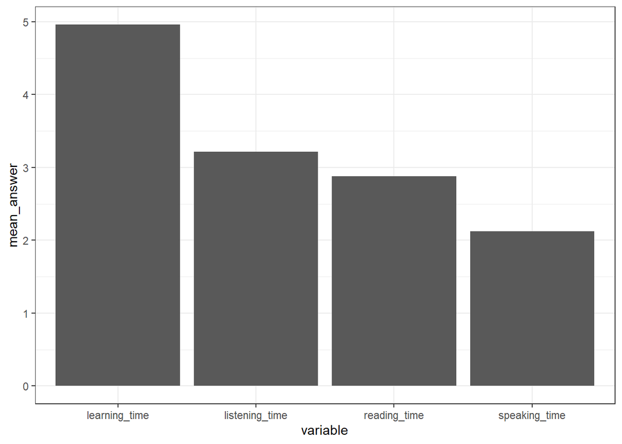

```
## # A tibble: 4 x 2
##   variable       mean_answer
##   <chr>                <dbl>
## 1 learning_time         4.96
## 2 listening_time        3.22
## 3 reading_time          2.88
## 4 speaking_time         2.12
```

```r
objective_language <- d_individual_summary %>% gather(key=variable, value = value, c("reading_time","listening_time", "speaking_time", "learning_time"))
objective_language_count <- objective_language %>% group_by(variable) %>% summarise(mean_answer = mean(value))
objective_language_count
objective_language_count %>% ggplot() + geom_bar(mapping = aes(x=variable,y =mean_answer),stat = "identity") + theme_bw()
```

For Learning time:

(1: 0-2 years, 2: 2-5 years, 3: 5-7 years, 4: 7-10 years, 5: 10-15 years, 6: more than 15 years)

For Reading/Listening/Speaking time:

(1: 0-4 hours/month, 2: 1-2 hours/week, 3: 3-5 hours/week, 4: 6-10 hours/week, 5: more than 10 hours/week)

# Bayesian Regression

## Creating and comparing models

```r
#brms model creation

fit_sc1 <- brm(
formula = response ~ type*language_eq,
data = new_data,
family = cumulative("logit")
)
```

```r
fit_sc2 <- brm(
formula = response ~ type * language_eq  + (1|subject_id),
data = new_data,
family = cumulative("logit")
)
```

```r
(loo(fit_sc1,fit_sc2))
```

```
## Output of model 'fit_sc1':
##
## Computed from 4000 by 2542 log-likelihood matrix
##
##          Estimate   SE
## elpd_loo  -4290.0 31.5
## p_loo        19.6  0.4
## looic      8580.0 63.0
## ------
## Monte Carlo SE of elpd_loo is 0.1.
##
## All Pareto k estimates are good (k < 0.5).
## See help('pareto-k-diagnostic') for details.
##
## Output of model 'fit_sc2':
##
## Computed from 4000 by 2542 log-likelihood matrix
##
##          Estimate   SE
## elpd_loo  -4103.1 34.9
## p_loo        86.5  1.5
## looic      8206.1 69.8
## ------
## Monte Carlo SE of elpd_loo is 0.1.
##
## All Pareto k estimates are good (k < 0.5).
## See help('pareto-k-diagnostic') for details.
##
## Model comparisons:
##         elpd_diff se_diff
## fit_sc2    0.0       0.0
## fit_sc1 -187.0      18.9
```

In the model comparisons we see fit_sc2 with elpd_diff and se_diff of 0.Therefore, we will continue our analysis with fit_sc2

```r
fit_sc2
```

```
##  Family: cumulative
##   Links: mu = logit; disc = identity
## Formula: response ~ type * language_eq + (1 | subject_id)
##    Data: new_data (Number of observations: 2542)
## Samples: 4 chains, each with iter = 2000; warmup = 1000; thin = 1;
##          total post-warmup samples = 4000
##
## Group-Level Effects:
## ~subject_id (Number of levels: 74)
##               Estimate Est.Error l-95% CI u-95% CI Eff.Sample Rhat
## sd(Intercept)     0.83      0.08     0.68     1.01       1241 1.00
##
## Population-Level Effects:
##                               Estimate Est.Error l-95% CI u-95% CI
## Intercept[1]                     -4.46      0.27    -4.98    -3.93
## Intercept[2]                     -3.32      0.25    -3.81    -2.83
## Intercept[3]                     -2.47      0.25    -2.95    -2.00
## Intercept[4]                     -1.69      0.24    -2.17    -1.22
## Intercept[5]                     -0.69      0.24    -1.17    -0.21
## Intercept[6]                      0.67      0.24     0.19     1.13
## typegustatory                    -1.22      0.23    -1.66    -0.79
## typemotor                        -0.21      0.23    -0.67     0.25
## typeolfactory                    -1.54      0.23    -2.00    -1.07
## typeorganic                      -0.44      0.23    -0.90     0.02
## typetactile                      -0.93      0.23    -1.39    -0.48
## typevisual                       -0.61      0.23    -1.07    -0.14
## language_eqTRUE                  -0.10      0.30    -0.68     0.49
## typegustatory:language_eqTRUE     0.76      0.28     0.22     1.30
## typemotor:language_eqTRUE         0.39      0.29    -0.17     0.95
## typeolfactory:language_eqTRUE     0.24      0.29    -0.33     0.81
## typeorganic:language_eqTRUE       0.93      0.29     0.37     1.51
## typetactile:language_eqTRUE       0.44      0.29    -0.12     1.00
## typevisual:language_eqTRUE        0.35      0.29    -0.23     0.92
##                               Eff.Sample Rhat
## Intercept[1]                        1426 1.00
## Intercept[2]                        1376 1.00
## Intercept[3]                        1332 1.00
## Intercept[4]                        1334 1.00
## Intercept[5]                        1339 1.00
## Intercept[6]                        1357 1.00
## typegustatory                       1845 1.00
## typemotor                           1802 1.00
## typeolfactory                       1824 1.00
## typeorganic                         2059 1.00
## typetactile                         1925 1.00
## typevisual                          2077 1.00
## language_eqTRUE                     1298 1.00
## typegustatory:language_eqTRUE       1903 1.00
## typemotor:language_eqTRUE           1896 1.00
## typeolfactory:language_eqTRUE       1881 1.00
## typeorganic:language_eqTRUE         1941 1.00
## typetactile:language_eqTRUE         1878 1.00
## typevisual:language_eqTRUE          1933 1.00
##
## Samples were drawn using sampling(NUTS). For each parameter, Eff.Sample
## is a crude measure of effective sample size, and Rhat is the potential
## scale reduction factor on split chains (at convergence, Rhat = 1).
```

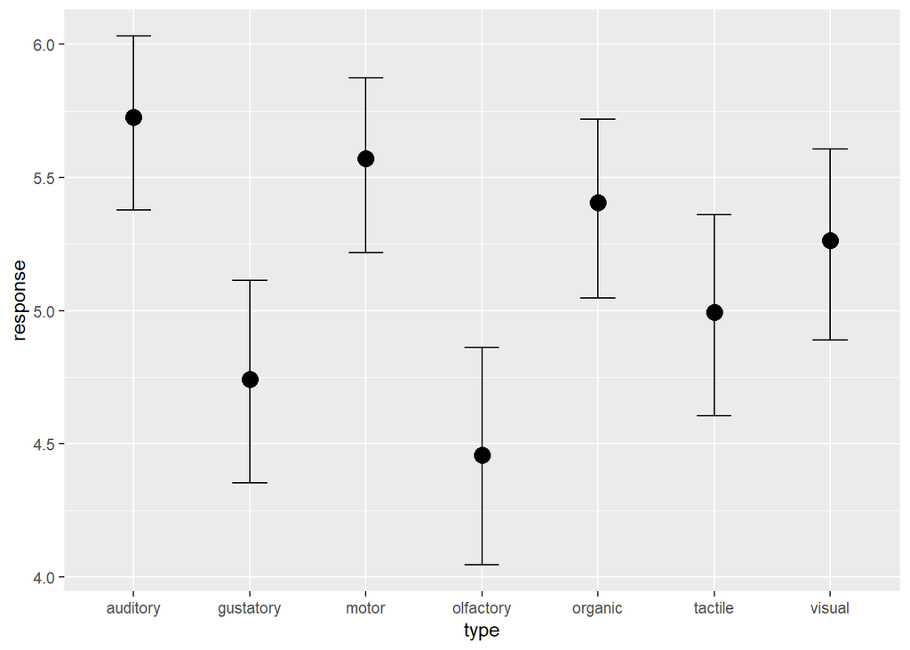

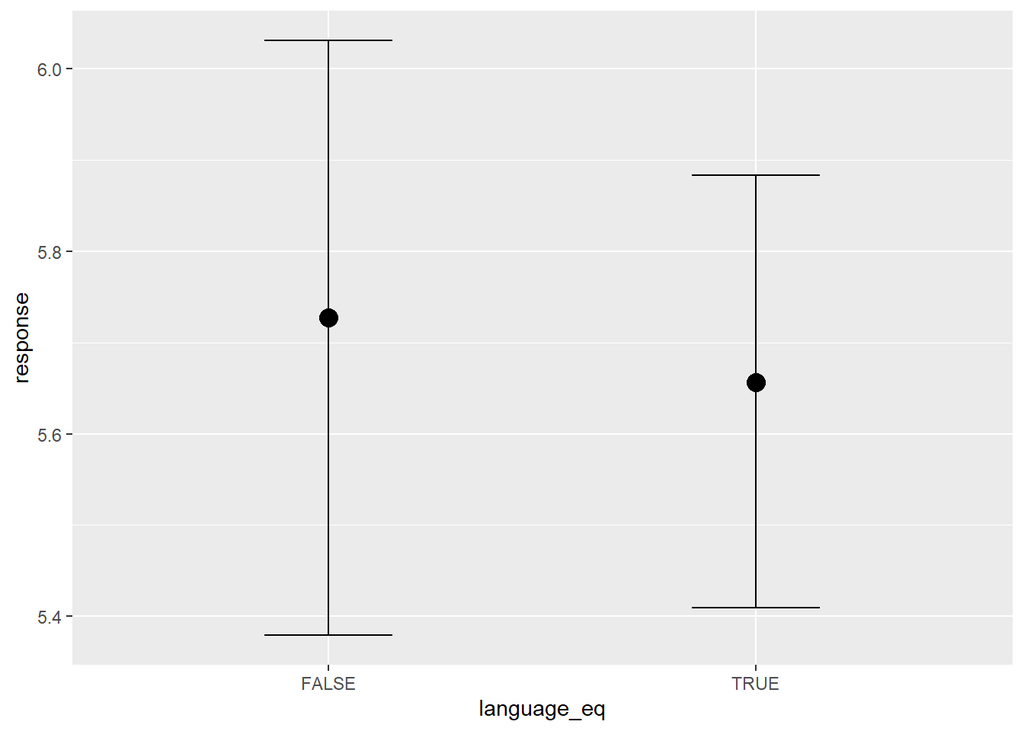

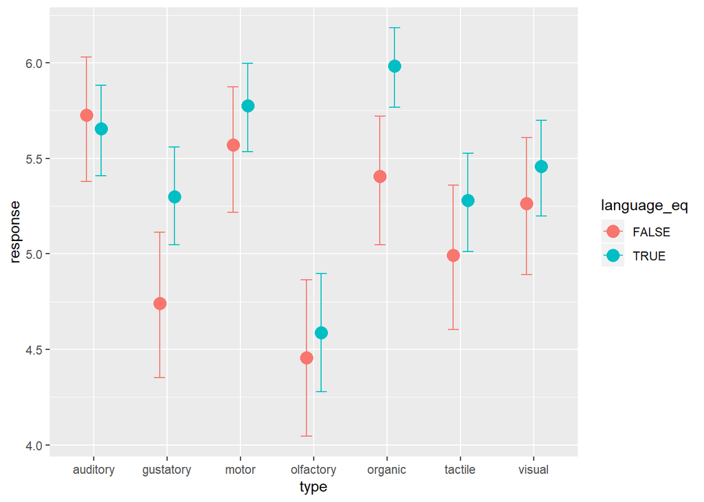

```r
effects2 <- marginal_effects(fit_sc2)
effects2
```

## Testing the hypothesis

Remember: “language_eq” = TRUE means the participant performed the Experiment in their native language

### Main hypothesis:

#### H1:

We hypothesize that using a foreign language reduces the vividness of mental imagery or simulations compared to the vividness of mental imagery or stimulation evoked by the usage of the native language: H1: On average the overall-ratings for “vividness” in the condition “foreign language” are smaller than in the condition “native language”.

##### First look at the average responses:

```r
analyse_data <- new_data %>% mutate(response = as.integer(response))
analyse_data %>% group_by(language_eq) %>% summarise(mean_response=mean(response), median_response = median((response)))
```

```
## # A tibble: 2 x 3
##   language_eq mean_response median_response
##   <lgl>               <dbl>           <int>
## 1 FALSE                5.06               5
## 2 TRUE                 5.41               6
```

##### testing for significance

We are not sure on how to deal with this hypothesis, since our model shows us the interaction of language with each modality (effects2$`type:language_eq):

```r
effects2$`type:language_eq` %>% select(type, language_eq, estimate__,lower__,upper__,se__)
```

```
##           type language_eq estimate__  lower__  upper__      se__
## .x1   auditory       FALSE   5.727353 5.378876 6.031142 0.1662414
## .x2   auditory        TRUE   5.656168 5.409336 5.883610 0.1236919
## .x3  gustatory       FALSE   4.741875 4.353075 5.114052 0.1954876
## .x4  gustatory        TRUE   5.298673 5.046882 5.559023 0.1344254
## .x5      motor       FALSE   5.571005 5.218106 5.873614 0.1661196
## .x6      motor        TRUE   5.775701 5.533663 5.996710 0.1139304
## .x7  olfactory       FALSE   4.457369 4.044923 4.863099 0.2188605
## .x8  olfactory        TRUE   4.587421 4.279551 4.895863 0.1578753
## .x9    organic       FALSE   5.405513 5.048530 5.719528 0.1817785
## .x10   organic        TRUE   5.983786 5.767647 6.182917 0.1101513
## .x11   tactile       FALSE   4.994007 4.604524 5.359551 0.1938884
## .x12   tactile        TRUE   5.279136 5.011267 5.526994 0.1352169
## .x13    visual       FALSE   5.263038 4.890576 5.607927 0.1886857
## .x14    visual        TRUE   5.458113 5.198481 5.699426 0.1261330
```

This shows us the overall possible combinations of each modality with either native or foreign language and their respective estimate, lower bound and upper bound. We will use this table for later hypothesis extensively. For H1 however, we need to know if the difference of language_eq=False and language_eq=True is significant over all hypothesis.

Our Hypothesis can be translated to: On average the overall-ratings for “vividness” in the condition language_eq=False are smaller than in the condition language_eq=True. To see if this hold we look at the average (mean) values over all modalities:

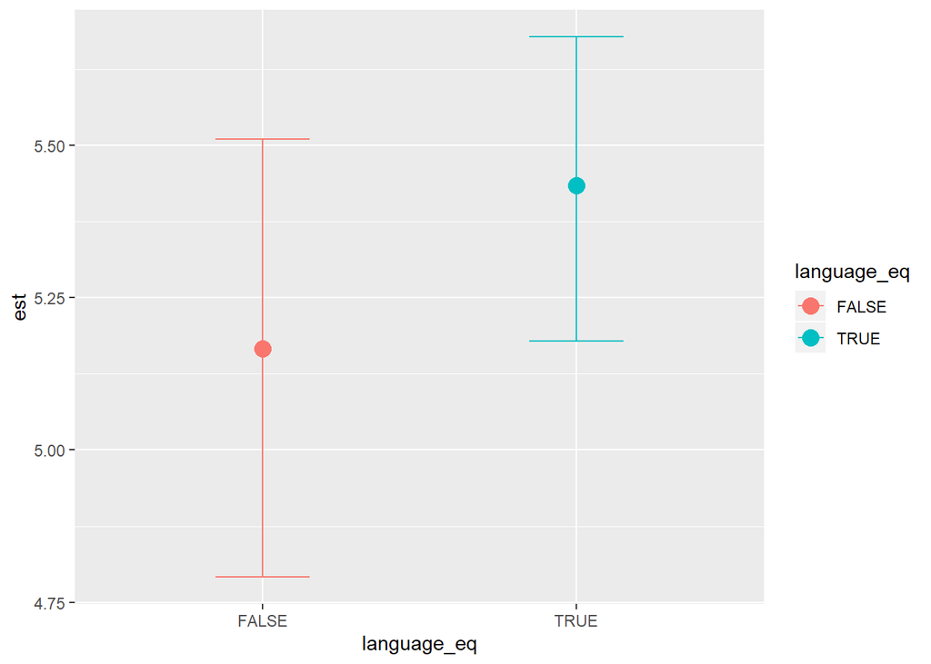

```r
language_effects <- effects2$`type:language_eq` %>% group_by(language_eq) %>% summarise(est = mean(estimate__), low=mean(lower__), upper = mean(upper__))
language_effects_plot<-ggplot(language_effects, aes(x=language_eq,color=language_eq)) + geom_errorbar(aes(ymin=low,ymax=upper),width = 0.3) +geom_point(aes(y=est),size=4)
language_effects_plot
```

```r
language_effects
```

```
## # A tibble: 2 x 4
##   language_eq   est   low upper
##   <lgl>       <dbl> <dbl> <dbl>
## 1 FALSE        5.17  4.79  5.51
## 2 TRUE         5.43  5.18  5.68
```

We doupt the accuracy of the result for the following reason:

##### The (probable) problem of using the mean:

In “Specific Criterion”->“Criteria iv” we excluded every sentence that received the answer “I don’t know the answer” because this sentence does not include any information about vividness of the mental image the participant had, simply because he/she didn’t understood the question. This results in the fact that the amount of answer for each modality we received is different of each modality!

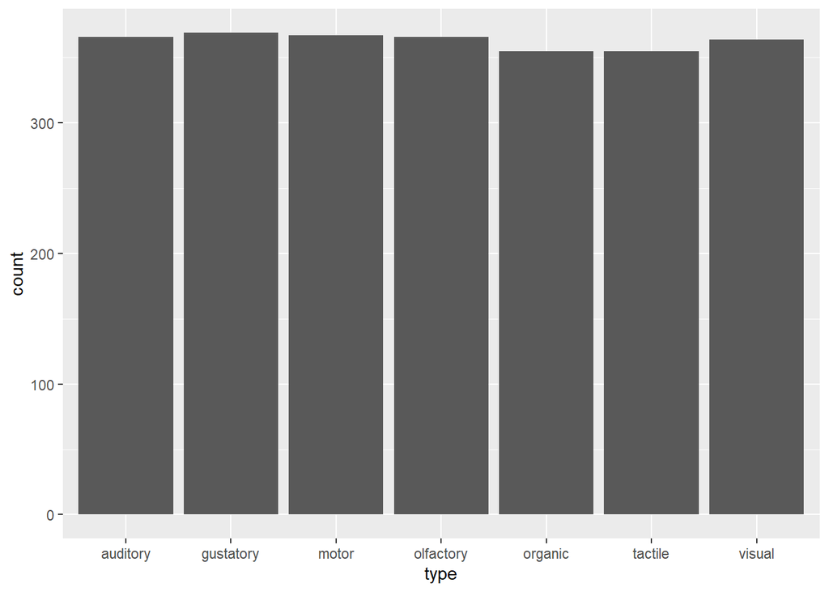

```
## # A tibble: 7 x 2
##   type      response_count
##   <fct>              <int>
## 1 auditory             366
## 2 gustatory            369
## 3 motor                367
## 4 olfactory            366
## 5 organic              355
## 6 tactile              355
## 7 visual               364
```

```r
new_data %>% group_by(type) %>% summarise(response_count = n())
new_data %>% group_by(type) %>% ggplot(aes(x=type)) + geom_bar()
```

The amount of answered sentences for each modality varies. Therefore, we think it might be problematic to just use the mean() function to calculate the overall estimate + lower and upper bound.

#### H2:

Furthermore we hypothesize, that the vividness of mental imagery or simulation of a (sensory) experience differs across different modalities between the two types of language: H2: On average the modality-specific-ratings for “vividness” in the condition “foreign language” are smaller (less vivid) than in the condition “native language” (more vivid).

Here compare if the estimate of each modality for the condition language_eq=False is within the boundaries of language_eq=True of the same modality.

```r
modality_effects <- effects2$`type:language_eq` %>% group_by(type) %>% summarise(estimate = mean(estimate__), low=mean(lower__), upper = mean(upper__))

#check for each modality if estimate of language_eq = False is lower than the lower bound of language_eq = True
modality_effects<-modality_effects %>% mutate(language_significants_within_modality = (effects2$`type:language_eq`[effects2$`type:language_eq`$language_eq == FALSE,]$estimate__ < effects2$`type:language_eq`[effects2$`type:language_eq`$language_eq == TRUE,]$lower__))

#Plotting for visualisation
modality_language_plot <-ggplot(effects2$`type:language_eq`, aes(x=type,color=language_eq)) + geom_errorbar(position= position_dodge(0.5),aes(ymin=lower__,ymax=upper__),width = 0.3) +geom_point(position= position_dodge(0.5),aes(y=estimate__),size=4)

modality_language_plot
```

[output not shown]

```r
modality_effects
```

```
## # A tibble: 7 x 5
##   type      estimate   low upper language_significants_within_modality
##   <fct>        <dbl> <dbl> <dbl> <lgl>
## 1 auditory      5.69  5.39  5.96 FALSE
## 2 gustatory     5.02  4.70  5.34 TRUE
## 3 motor         5.67  5.38  5.94 FALSE
## 4 olfactory     4.52  4.16  4.88 FALSE
## 5 organic       5.69  5.41  5.95 TRUE
## 6 tactile       5.14  4.81  5.44 TRUE
## 7 visual        5.36  5.04  5.65 FALSE
```

One can see that this holds only for gustatory, organic and tactile. We conclude that H2 is false. It does hold for some, but not for all modalities!

### Hypothesis of relationships between variables:

#### H3:

Moreover, we suggest that sensory experiences are easier (more vividly) to simulate for some modalities compared to other modalities. H3: More specific, we hypothesize that mental images evoked by visual simulations have higher vividness-ratings than those evoked by the other six modalities

When only looking at the mean response of the different modalities one can see that the visual response rating is not the highest.

```r
analyse_data %>% group_by(type) %>% summarise(mean_response = mean(response))
```

```
## # A tibble: 7 x 2
##   type      mean_response
##   <fct>             <dbl>
## 1 auditory           5.57
## 2 gustatory          5.09
## 3 motor              5.66
## 4 olfactory          4.50
## 5 organic            5.75
## 6 tactile            5.12
## 7 visual             5.30
```

If one looks at the output plot of the marginal effects2$type:language_eq:

```r
effects2$`type:language_eq` %>% select(type, language_eq,estimate__,lower__,upper__)
modality_language_plot
```

```
##           type language_eq estimate__  lower__  upper__
## .x1   auditory       FALSE   5.727353 5.378876 6.031142
## .x2   auditory        TRUE   5.656168 5.409336 5.883610
## .x3  gustatory       FALSE   4.741875 4.353075 5.114052
## .x4  gustatory        TRUE   5.298673 5.046882 5.559023
## .x5      motor       FALSE   5.571005 5.218106 5.873614
## .x6      motor        TRUE   5.775701 5.533663 5.996710
## .x7  olfactory       FALSE   4.457369 4.044923 4.863099
## .x8  olfactory        TRUE   4.587421 4.279551 4.895863
## .x9    organic       FALSE   5.405513 5.048530 5.719528
## .x10   organic        TRUE   5.983786 5.767647 6.182917
## .x11   tactile       FALSE   4.994007 4.604524 5.359551
## .x12   tactile        TRUE   5.279136 5.011267 5.526994
## .x13    visual       FALSE   5.263038 4.890576 5.607927
## .x14    visual        TRUE   5.458113 5.198481 5.699426
```

it seems obvious that H3 is false. One can see clearly that the rating of vividness for “visual” is not significantly higher than all the other modalities. It is significantly higher than olfactory for both native and foreign language and significantly higher than gustatory for foreign laguage but not native language.

If we assume, like in H1, that using the mean is a correct way to average over the language_eq we get the following result:

```r
modality_effects <- effects2$`type:language_eq` %>% group_by(type) %>% summarise(estimate = mean(estimate__), low=mean(lower__), upper = mean(upper__))
modality_plot <- ggplot(modality_effects, aes(x=type,color=type)) + geom_errorbar(aes(ymin=low,ymax=upper),width = 0.2) +geom_point(aes(y=estimate),size=4)
modality_effects
modality_plot
```

```
## # A tibble: 7 x 4
##   type      estimate   low upper
##   <fct>        <dbl> <dbl> <dbl>
## 1 auditory      5.69  5.39  5.96
## 2 gustatory     5.02  4.70  5.34
## 3 motor         5.67  5.38  5.94
## 4 olfactory     4.52  4.16  4.88
## 5 organic       5.69  5.41  5.95
## 6 tactile       5.14  4.81  5.44
## 7 visual        5.36  5.04  5.65
```

This result indicates that H3 is wrong since the estimate for type=visual is not significantly larger than the upper bound of all other modalities:

```r
modality_effects %>% mutate(visual_significant = modality_effects[7,]$estimate >modality_effects$upper)
```

```
## # A tibble: 7 x 5
##   type      estimate   low upper visual_significant
##   <fct>        <dbl> <dbl> <dbl> <lgl>
## 1 auditory      5.69  5.39  5.96 FALSE
## 2 gustatory     5.02  4.70  5.34 TRUE
## 3 motor         5.67  5.38  5.94 FALSE
## 4 olfactory     4.52  4.16  4.88 TRUE
## 5 organic       5.69  5.41  5.95 FALSE
## 6 tactile       5.14  4.81  5.44 FALSE
## 7 visual        5.36  5.04  5.65 FALSE
```

However it would also classify visual as significantly higher as gustatory. So the result is similiar to the one using effects2$`type:language_eq`.

#### H4:

We also think that sensory experiences are harder (less vividly) imagined for some modalities compared to other modalities. H4: Here we think that mental simulations evoked by the olfactory or gustatory modality have lower vividness-ratings than those evoked by the other five modalities

```r
modality_language_plot
```

[output not shown]

This hypothesis states that the olfactory estimate and gustatory ratings are significantly lower than the other modalities. In the given graph one can see that this does only hold for olfactory when also considering the language type. Within language_eq = Flase (orange) the olfactory ratings are significantly smaller than the other modalities (exepct gustatory). For language_eq = true (native) it is significantly smaller compared to all modalities.

```r
modality_plot
```

[output not shown]

```r
modality_effects %>%  mutate(gustatory_significant_lower = modality_effects[2,]$estimate < modality_effects$low,olfactory_significant_lower = modality_effects[4,]$estimate < modality_effects$low)
```

```
## # A tibble: 7 x 6
##   type    estimate   low upper gustatory_significant~ olfactory_significan~
##   <fct>      <dbl> <dbl> <dbl> <lgl>                  <lgl>
## 1 audito~     5.69  5.39  5.96 TRUE                   TRUE
## 2 gustat~     5.02  4.70  5.34 FALSE                  TRUE
## 3 motor       5.67  5.38  5.94 TRUE                   TRUE
## 4 olfact~     4.52  4.16  4.88 FALSE                  FALSE
## 5 organic     5.69  5.41  5.95 TRUE                   TRUE
## 6 tactile     5.14  4.81  5.44 FALSE                  TRUE
## 7 visual      5.36  5.04  5.65 TRUE                   TRUE
```

If we compare this to the modality_plot that uses the mean to average over the language we can see a different result. The olfactory rating is significantly smaller than all other modalities in the modeality plot.

In the case of gustatory, it is significantly lower than auditory, motor, organic and also visual (which was only the case for foreign language in modality_language_plot)

We can say that H4 is partly true, since olfactory got a significantly lower vividness rating compared to the rest of the modalities. This however does not hold for the gustatory modality.

## Further remarks

### Trying alternative Methods/Models

As H1 stated, we are interested of the influence on vividness when using a foreign language. Above we used a brm model that showed us the interaction of type and language_eq (fit_sc2). In order to get the information about language_eq without the influence of the modality types, we average over the modalities. We are not sure whether this is methodological correct.

#### foreign vs. native Language

Below we use a brm model that completly ignores the type of modalities. We want to know whether the results would be similiar to the ones from fit_sc2 and averaging

```r
fit_sc3  <- brm(
formula = response ~ language_eq + (1|subject_id),
data = new_data,
family = cumulative("logit")
)

'fit_sc2 <- brm(
formula = response ~ type * language_eq  + (1|subject_id),
data = new_data,
family = cumulative("logit")
)

and

language_effects <- effects2$`type:language_eq` %>% group_by(language_eq) %>% summarise(est = mean(estimate__), low=mean(lower__), upper = mean(upper__))'

effects3 <- marginal_effects(fit_sc3)
language_effects2 <- effects3$language_eq %>%  select(language_eq,estimate__,lower__,upper__)

#compute the difference for each cell
result <- language_effects2[,2:4] - language_effects[,2:4]
result
```

```
## [1] "fit_sc2 <- brm(\nformula = response ~ type * language_eq  + (1|subject_id),\ndata = new_data,\nfamily = cumulative(\"logit\")\n)\n\nand \n\nlanguage_effects <- effects2$`type:language_eq` %>% group_by(language_eq) %>% summarise(est = mean(estimate__), low=mean(lower__), upper = mean(upper__)…
##        estimate__    lower__     upper__
## .x1  8.173218e-05 0.10035958 -0.08562042
## .x2 -1.105508e-03 0.04046108 -0.05243297
```

One can see that the difference is very small! So using the mean() to create langauge_effects seems to be a way to approximate language_effects2. We are, however, not sure if this is still the correct model to test for significance.

#### Modality comparison

Below, we try out the same like above to see if the same observation can be made for the modalities.

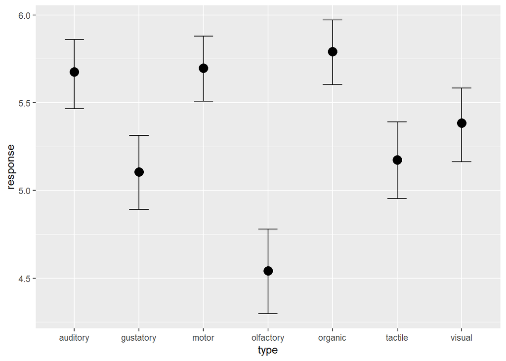

```r
fit_sc4  <- brm(
formula = response ~ type + (1|subject_id),
data = new_data,
family = cumulative("logit")
)

'fit_sc2 <- brm(
formula = response ~ type * language_eq  + (1|subject_id),
data = new_data,
family = cumulative("logit")
)

and

language_effects <- effects2$`type:language_eq` %>% group_by(language_eq) %>% summarise(est = mean(estimate__), low=mean(lower__), upper = mean(upper__))'

effects4 <- marginal_effects(fit_sc4)
effects4
```

```r
modality_effects2 <- effects4$type %>%  select(type,estimate__,lower__,upper__)

modality_effects
#compute the difference for each cell
result2 <- modality_effects2[,2:4] - modality_effects[,2:4]
result2
```

```
## [1] "fit_sc2 <- brm(\nformula = response ~ type * language_eq  + (1|subject_id),\ndata = new_data,\nfamily = cumulative(\"logit\")\n)\n\nand \n\nlanguage_effects <- effects2$`type:language_eq` %>% group_by(language_eq) %>% summarise(est = mean(estimate__), low=mean(lower__), upper = mean(upper__)…
## # A tibble: 7 x 4
##   type      estimate   low upper
##   <fct>        <dbl> <dbl> <dbl>
## 1 auditory      5.69  5.39  5.96
## 2 gustatory     5.02  4.70  5.34
## 3 motor         5.67  5.38  5.94
## 4 olfactory     4.52  4.16  4.88
## 5 organic       5.69  5.41  5.95
## 6 tactile       5.14  4.81  5.44
## 7 visual        5.36  5.04  5.65
##      estimate__    lower__     upper__
## .x1 -0.01609511 0.07213169 -0.09700108
## .x2  0.08558517 0.19067249 -0.02377245
## .x3  0.02365768 0.13340850 -0.05670121
## .x4  0.01907964 0.13452553 -0.09914008
## .x5  0.09746912 0.19391226  0.01992245
## .x6  0.03825811 0.14610595 -0.05352937
## .x7  0.02438773 0.11908918 -0.06972873
```

Like above, the difference is very small. fit_sc4 seems to approximate fit_sc2 with averaging over the language

#### Visualising both

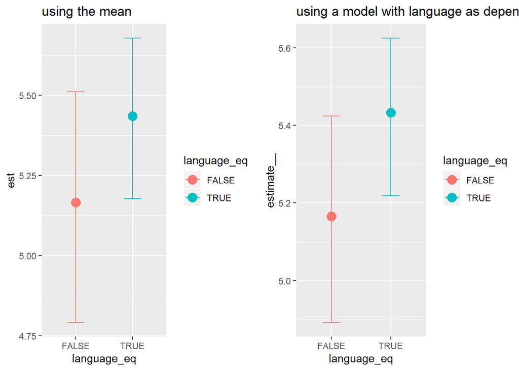

```r
#plotting the data before deleting and after
plot1<- language_effects_plot + ggtitle("using the mean")

plot2<-ggplot(language_effects2, aes(x=language_eq,color=language_eq)) + geom_errorbar(position= position_dodge(0.5),aes(ymin=lower__,ymax=upper__),width = 0.3) + geom_point(position= position_dodge(0.5),aes(y=estimate__),size=4) + ggtitle("using a model with language as dependent variable")

plot3<- modality_plot + ggtitle("using the mean")

plot4<- ggplot(modality_effects2, aes(x=type ,color=type)) + geom_errorbar(position= position_dodge(0.5),aes(ymin=lower__,ymax=upper__),width = 0.3) + geom_point(position= position_dodge(0.5),aes(y=estimate__),size=4) + ggtitle("using a model with type as dependent variable")



require(gridExtra)
grid.arrange(plot1,plot2,ncol=2)
```

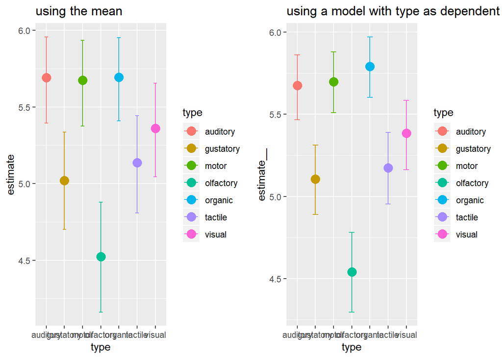

```r
grid.arrange(plot3,plot4,ncol=2)
```

```r
#grid.arrange(plot1,plot2,plot3,plot4,ncol=2,nrow=2)
```

#### Mann-Whitney-U test

In the original experiment the authors used a U-test to test for significance. Hence, below we tried if using a U test would show similiar results:

```r
#transform since the wilcox function requires numeric input

new_data_manu <- d_individual_summary %>%  select(response,language_eq)
new_data_manu

#testing
manu_language<-wilcox.test(new_data_manu$response ~ new_data_manu$language_eq, conf.level=0.95)
manu_language
n1=27
n2=47
U=452

# we need to calculate the z value because our n is larger than 20
z=(U-(n1*n2)/2)/sqrt((n1*n2*(n1+n2+1))/12)
z
abs(z)>1.96
```

```
## # A tibble: 74 x 2
##    response language_eq
##       <dbl> <lgl>
##  1     4.54 FALSE
##  2     5.69 FALSE
##  3     5.83 TRUE
##  4     6.66 FALSE
##  5     4.83 FALSE
##  6     5.29 TRUE
##  7     6.03 TRUE
##  8     5.2  FALSE
##  9     5.69 TRUE
## 10     4.82 FALSE
## # ... with 64 more rows
##
##  Wilcoxon rank sum test with continuity correction
##
## data:  new_data_manu$response by new_data_manu$language_eq
## W = 452, p-value = 0.04095
## alternative hypothesis: true location shift is not equal to 0
##
## [1] -2.049236
## [1] TRUE
```

The result of the Mann-Whitney-U test indicates a significant difference between foreign and native language. alpha = 0.05, p = 0.040946.

#### ANOVA

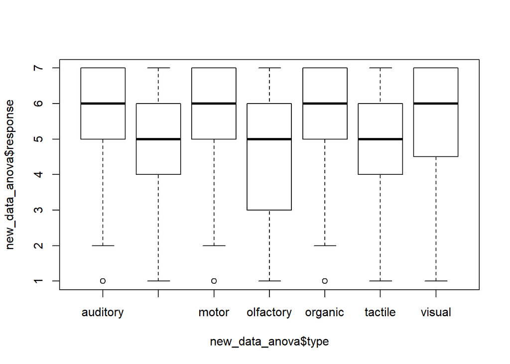

```r
new_data_anova <- new_data %>% select(response,type)
new_data_anova <- new_data_anova[order(new_data_anova$type),] %>% mutate(response=as.integer(response))



boxplot(new_data_anova$response~new_data_anova$type)
```

```r
summary(aov(data= new_data_anova, formula = response~type))
```

```
##               Df Sum Sq Mean Sq F value Pr(>F)
## type           6    410   68.27   27.73 <2e-16 ***
## Residuals   2535   6241    2.46
## ---
## Signif. codes:  0 '***' 0.001 '**' 0.01 '*' 0.05 '.' 0.1 ' ' 1
```

The result suggest that there is a significant difference between the different modalities.

##### Determine between which groups the difference is significant

```r
post_hoc<-TukeyHSD(aov(data= new_data_anova, formula = response~type))
post_hoc
```

```
##   Tukey multiple comparisons of means
##     95% family-wise confidence level
##
## Fit: aov(formula = response ~ type, data = new_data_anova)
##
## $type
##                            diff        lwr         upr     p adj
## gustatory-auditory  -0.48704962 -0.8285872 -0.14551210 0.0005310
## motor-auditory       0.09107964 -0.2509210  0.43308027 0.9863590
## olfactory-auditory  -1.07103825 -1.4132721 -0.72880442 0.0000000
## organic-auditory     0.18115909 -0.1637157  0.52603383 0.7142899
## tactile-auditory    -0.44982683 -0.7947016 -0.10495208 0.0023332
## visual-auditory     -0.27431994 -0.6170236  0.06838367 0.2153923
## motor-gustatory      0.57812927  0.2368254  0.91943311 0.0000128
## olfactory-gustatory -0.58398863 -0.9255262 -0.24245110 0.0000100
## organic-gustatory    0.66820871  0.3240249  1.01239250 0.0000002
## tactile-gustatory    0.03722279 -0.3069610  0.38140658 0.9999154
## visual-gustatory     0.21272968 -0.1292786  0.55473794 0.5240788
## olfactory-motor     -1.16211790 -1.5041185 -0.82011727 0.0000000
## organic-motor        0.09007944 -0.2545639  0.43472277 0.9876374
## tactile-motor       -0.54090647 -0.8855498 -0.19626315 0.0000781
## visual-motor        -0.36539959 -0.7078703 -0.02292887 0.0276673
## organic-olfactory    1.25219734  0.9073226  1.59707209 0.0000000
## tactile-olfactory    0.62121142  0.2763367  0.96608617 0.0000024
## visual-olfactory     0.79671831  0.4540147  1.13942192 0.0000000
## tactile-organic     -0.63098592 -0.9784815 -0.28349032 0.0000019
## visual-organic      -0.45547903 -0.8008200 -0.11013809 0.0019678
## visual-tactile       0.17550689 -0.1698340  0.52084782 0.7452298
```

```r
modality_plot
```

[output not shown]

### Restricting the participants

Our distribution of participants who did the experiment in their nativ vs foreign language is not equal. Below we delete randomly 20 participants who did the experiment in German and see if our model changes.

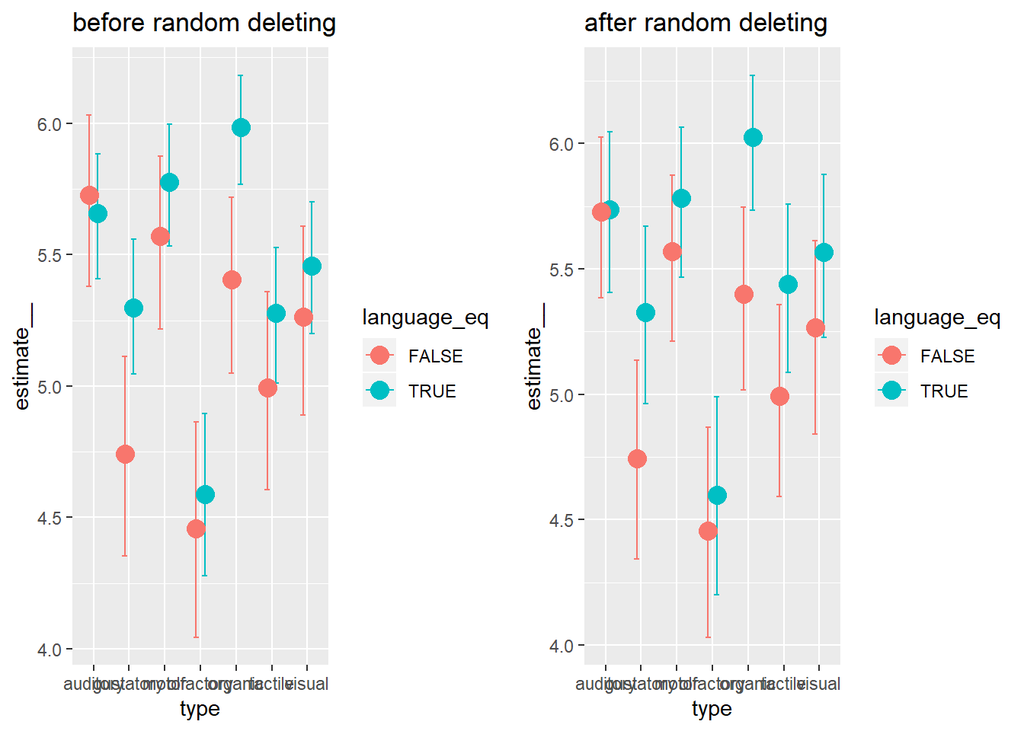

```r
#collecting 20 random subject_id's
d_individual_summary %>% group_by(exp_language) %>%  summarise(count = n())
tmp <- new_data %>% filter(exp_language == "German")
index <- tmp$subject_id
index <- sample(unique(index),20)

#randomly delete 20:
equal_data <- new_data[!(new_data$subject_id %in% index),]

#check if equal number of german and english
after_individual_summary <- group_by(equal_data,subject_id) %>%  summarise(exp_language = unique(exp_language))
after_individual_summary %>% group_by(exp_language) %>% summarise(count=n())

#run new model
fit_sc5 <-brm(
formula = response ~ type*language_eq   + (1|subject_id),
data = equal_data,
family = cumulative("logit")
)
effects5 <- marginal_effects(fit_sc5)

#get data
after_rndm_delete <- effects5$`type:language_eq` %>% select(type,language_eq,estimate__,lower__,upper__)
before_rndm_delete <- effects2$`type:language_eq` %>% select(type,language_eq,estimate__,lower__,upper__)

#calculate difference
difference <- before_rndm_delete[,3:5] - after_rndm_delete[,3:5]

#plotting the data before deleting and after
plot1<-ggplot(before_rndm_delete, aes(x=type,color=language_eq)) + geom_errorbar(position= position_dodge(0.5),aes(ymin=lower__,ymax=upper__),width = 0.3) + geom_point(position= position_dodge(0.5),aes(y=estimate__),size=4)+ ggtitle("before random deleting")

plot2<-ggplot(after_rndm_delete, aes(x=type,color=language_eq)) + geom_errorbar(position= position_dodge(0.5),aes(ymin=lower__,ymax=upper__),width = 0.3) + geom_point(position= position_dodge(0.5),aes(y=estimate__),size=4) + ggtitle("after random deleting")

require(gridExtra)
grid.arrange(plot1,plot2,ncol=2)
```

```r
difference
```

```
## # A tibble: 2 x 2
##   exp_language count
##   <chr>        <int>
## 1 English         27
## 2 German          47
## # A tibble: 2 x 2
##   exp_language count
##   <chr>        <int>
## 1 English         27
## 2 German          27
##         estimate__      lower__       upper__
## .x1  -0.0012705447 -0.006924383  0.0053016965
## .x2  -0.0797178014  0.003579146 -0.1622025170
## .x3  -0.0022419941  0.009105959 -0.0207103077
## .x4  -0.0269836792  0.082930636 -0.1126197459
## .x5   0.0005901397  0.006968080 -0.0011911361
## .x6  -0.0078227863  0.067980709 -0.0686863689
## .x7   0.0005045503  0.013278325 -0.0051195312
## .x8  -0.0092456357  0.078160391 -0.0953809984
## .x9   0.0041031861  0.030170674 -0.0267957657
## .x10 -0.0432959870  0.033703922 -0.0898091587
## .x11  0.0020084215  0.011320427  0.0009901389
## .x12 -0.1598536634 -0.075636804 -0.2322248536
## .x13 -0.0020726966  0.049565694 -0.0056603038
## .x14 -0.1086154418 -0.027848791 -0.1782801234
```

The difference is very small! There are differences but we do not consider them meaningfull.